# R Wheel Running Analysis

## Welcome!

This is an [R Markdown](http://rmarkdown.rstudio.com) Notebook built to help you analyze .log files from mouse wheel running experiments.

### How to use this notebook:

Set your settings in code chunk #2. Run code chunks 1-3 to set up and create your folder structure. Then dump all the .log files in the folder created by the script in `data` > `01_Raw_data`. Just put all mouse log files in the raw data folder. Then run the remaining code chunks in order.

When you execute code within the notebook, the results appear beneath the code. You can run code chunks one by one by clicking the *Run* button in the upper right corner of the chunk or by placing your cursor the code chunk and pressing *Ctrl+Shift+Enter*. To run all code chunks, you can *Ctrl+Alt+R* or hit the Run button and select “Run All” or “Restart R and Run all.”

### 📚 Setup Libraries

This code block loads necessary libraries and sets up the directory structure necessary for the project. You need to run it, but it is not included in your output notebook.

```
Skipping install of 'emo' from a github remote, the SHA1 (3f03b114) has not changed since last install.
  Use `force = TRUE` to force installation
```

```
 ✅ 1. 29 packages loaded
```

### ⚙️ Options for analysis – USER INPUT REQUIRED

- Select your options for your analysis in the code below. T for True, F for False.

```
Settings for Exp1 :
   Experiment name 🆔 : Exp1
         Lights On 🌅 : 7
        Lights Off 🌃 : 19
      Time change? ⏰ : TRUE

Time change settings: ⏰
     Day of change 📆 : 14
         Lights ON 🌅 : 7  ➡️ 7
        Lights OFF 🌃 : 19 ➡️ 12

 ✅ 2.  ⚙️ Settings loaded
```

### 📁 Make directory structure for the project

```
 ✅ 3. Made folder structure here: 📂 C:/Users/Rebecca/Documents/GitHub/Mouse-Wheel-Running-Analysis
```

### 🧹 Organize, Load, and Clean Data

This step organizes the mouse .log files into 1 folder per mouse, then loads the data into R and creates a metadata table from the data frames.

If you’d like to remove animals, now is the time to remove those folders from data > 02_Organized_data.

### 🔢 Add columns to data

This chunk takes your data for each mouse and adds additional variables, like speed, time of day, and experimental phase information. Data columns include:

- `expDay` (1, 2, 3…# of experimental days)
- `speed` (should be in meters/min)
- `elapsedDays` same as `expDay` but days can be fractional
- `hour` (clock time hour)
- `minutes` (clock time minutes)
- `activeFactor` (whether the animal is in its active phase (lights OFF -> TRUE))
- `t` (time in seconds since the first lights ON (can precede the start of the recording)
- `expPhase` (which experimental phase each time point belongs to)
- `moving` (whether that individual animal moved during that 10 second period))

### 📆 Experimental timeline

### 📈 Make graphs

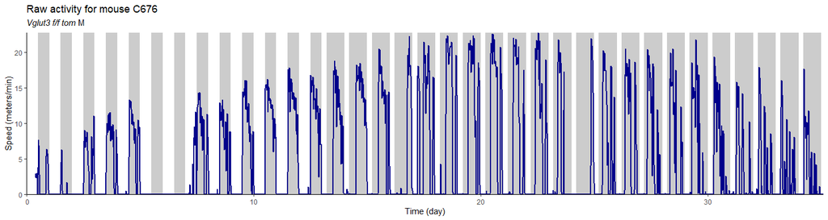

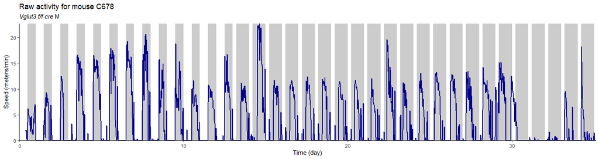

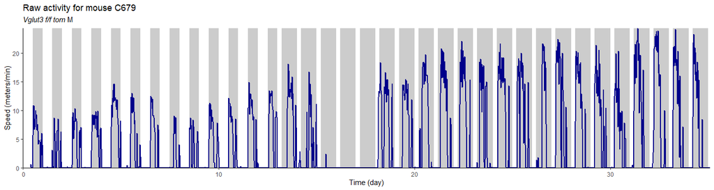

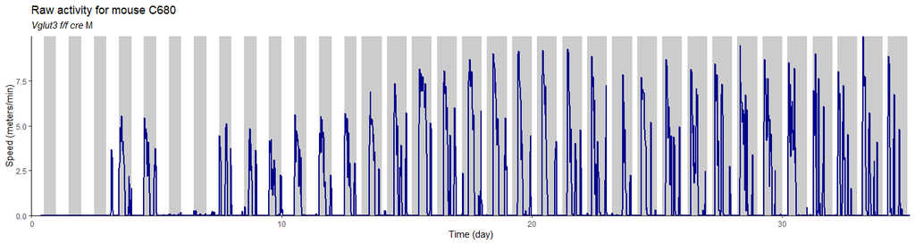

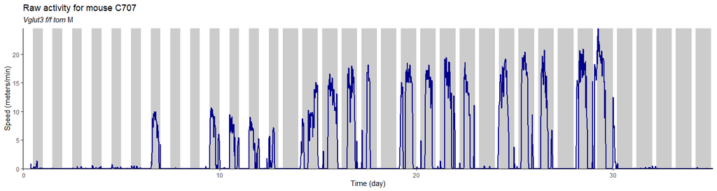

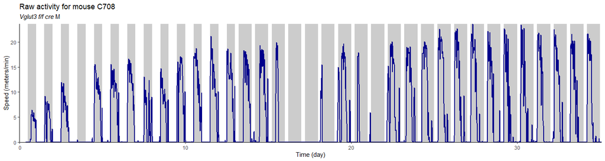

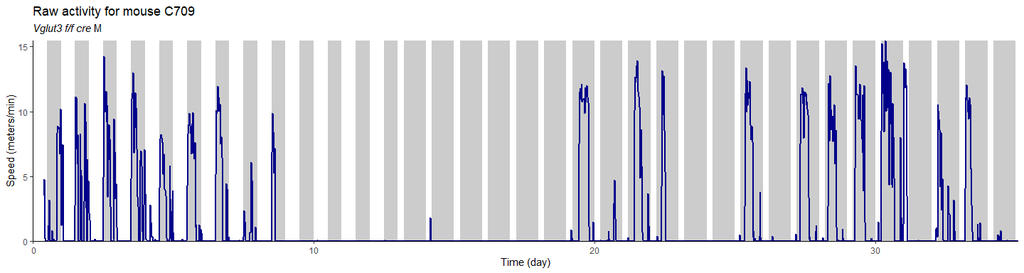

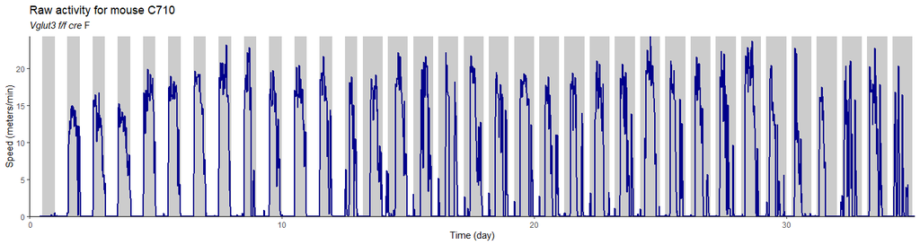

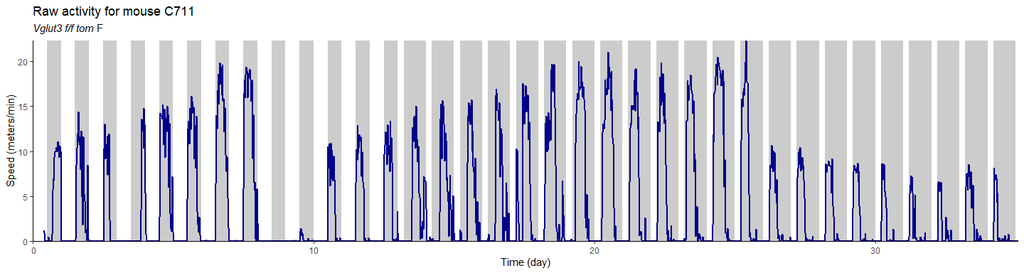

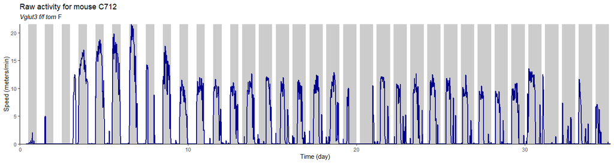

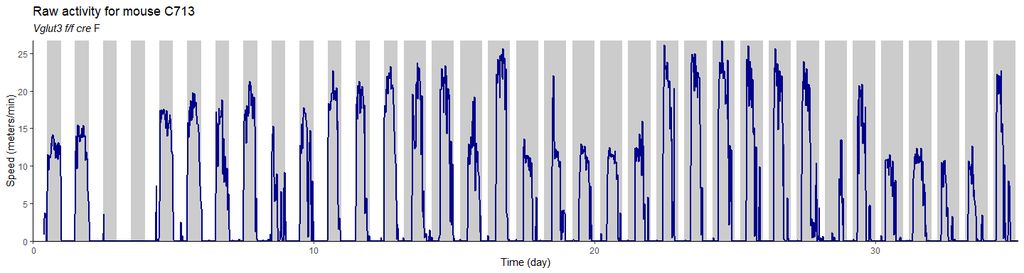

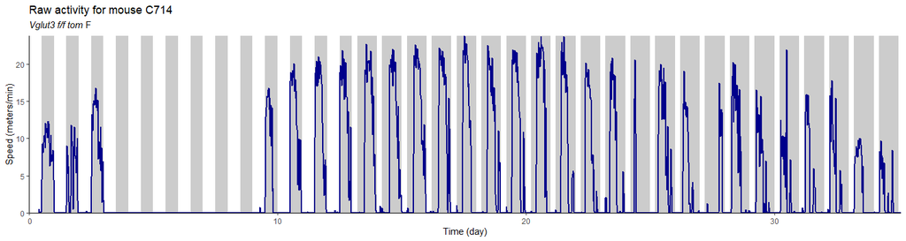

[10 more figures not shown]

[output not shown]

### 📑 Methods and References